# Quantified self movement analysis

MLMV

29 January 2017

### Executive summary

Using Fitbit or similar devices, many people like to quantify how much of a particular activity they do. However they rarely quantify *how well* they do it. In this project, our goal is to use data from accelerometers on the belt, forearm, arm, and dumbell of 6 participants who were asked to perform barbell lifts in 5 different ways correctly and incorrectly, and to build a model that can predict the manner in which they did the exercise.

### Data & exploratory analysis

The data for this project comes from http://groupware.les.inf.puc-rio.br/har#weight_lifting_exercises.

```r
training = read.csv("pml-training.csv", na = c("", "NA"))
testing = read.csv("pml-testing.csv", na = c("", "NA"))
```

Before starting the modeling, we do some data profiling. The data consists of 160 variables, with 19622 observations in a training set and 20 additional observations in a testing set. The outcome variable “classe” is roughly evenly distributed, overall and across users, with some prevalence for classe A.

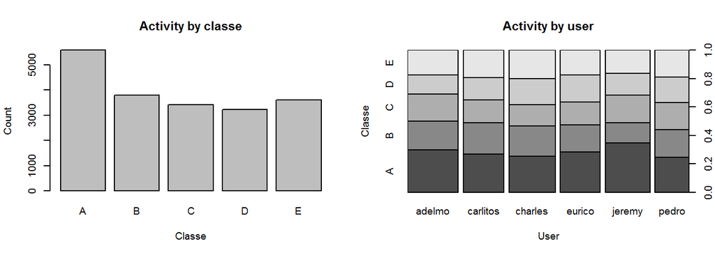

```r
par(mfrow = c(1,2), cex = 0.6)
barplot(table(training$classe), main = "Activity by classe", xlab = "Classe", ylab = "Count")
plot(classe ~ user_name, data = training, main = "Activity by user", xlab = "User", ylab = "Classe")
```

We also find that are 100 variables with missing values in the set; with a proportion of missing values as high as 98 percent. (For the code used to quantify missing values, refer to the appendix.) For such variables an imputation strategy will not give reasonable results, so we will omit them from our prediction models. As the first column is only a record ID with no relation to the outcome, we will omit that too. This leaves us with 58 predictor variables and the outcome.

```r
NAcols <- c(1, which(colSums(is.na(training)) > 0))
newtraining <- training[,-NAcols]
newtesting <- testing[,-NAcols]
```

### Model selection and training

```r
set.seed(54321)
fit1 <- train(classe ~., method = "rf", data = newtraining, trControl = trainControl(method = "cv"), number = 3, importance = TRUE, ntree = 10)
```

### Model evaluation

The resulting random forest is summarized as follows.

```r
print(fit1, digits = 3)
```

```
## Random Forest
##
## 19622 samples
##    58 predictor
##     5 classes: 'A', 'B', 'C', 'D', 'E'
##
## No pre-processing
## Resampling: Cross-Validated (10 fold)
## Summary of sample sizes: 17659, 17660, 17659, 17661, 17659, 17659, ...
## Resampling results across tuning parameters:
##
##   mtry  Accuracy  Kappa
##    2    0.978     0.973
##   41    0.999     0.999
##   80    0.998     0.998
##
## Accuracy was used to select the optimal model using  the largest value.
## The final value used for the model was mtry = 41.
```

By using the varImp function we can evaluate which features have the greatest importance within the model.

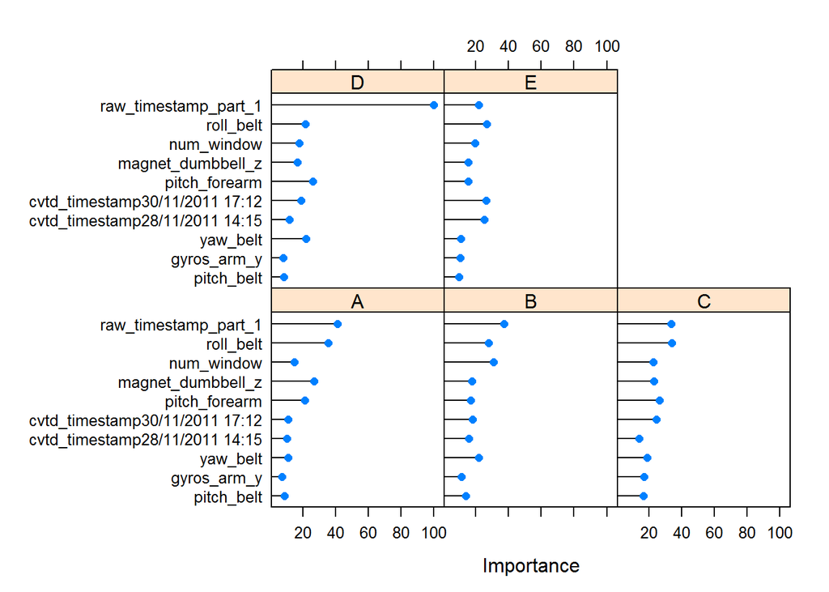

```r
varI <- varImp(fit1, conditional = TRUE)
plot(varI, top = 10)
```

We can evaluate the model performance by looking at the ‘finalmodel’ component. The confusion matrix indicates that in the vast majority of cases, we have correctly predicted the outcomes. The estimated out of bag error rate is 0.42%.

```r
fit1$finalModel
```

```
##
## Call:
##  randomForest(x = x, y = y, ntree = 10, mtry = param$mtry, importance = TRUE,      number = 3)
##                Type of random forest: classification
##                      Number of trees: 10
## No. of variables tried at each split: 41
##
##         OOB estimate of  error rate: 0.42%
## Confusion matrix:
##      A    B    C    D    E class.error
## A 5505    5    2    2    0 0.001632209
## B   10 3725   12    0    4 0.006931485
## C    2   17 3377    3    1 0.006764706
## D    2    1    6 3152    7 0.005050505
## E    0    0    0    8 3561 0.002241524
```

### Prediction

Finally, we use the predict function to predict the 20 different test cases.

```r
pred1 <- predict(fit1, newtesting)
pred1
```

```
##  [1] B A B A A E D B A A B C B A E E A B B B
## Levels: A B C D E
```

### Appendix

#### References

- Velloso, E.; Bulling, A.; Gellersen, H.; Ugulino, W.; Fuks, H. Qualitative Activity Recognition of Weight Lifting Exercises. Proceedings of 4th International Conference in Cooperation with SIGCHI (Augmented Human ’13) . Stuttgart, Germany: ACM SIGCHI, 2013.

#### Code for quantifying missing values

- How many variables have missing values? `length(which(colSums(is.na(training)) > 0))`
- How many missing values in each variable? `sapply(training, function(x) sum(is.na(x)))`